# PS5 (Oct 20)

Jamie Duncan

15/10/2020

##### Section 1

###### Question 1

```r
intrade.n3 <- intrade %>% #subsetting for just november 3rd and calculating pij (as ppd)
  filter(day == "2008-11-03") %>%
  mutate(ppd = PriceD / 100)

intrade.n3$state.name <- intrade.n3$statename #renaming the statename column

pred08 <- merge(intrade.n3, pres, by = "state.name") #merging the two datasets

pred08.rel <- pred08 %>%
  select(state.name, ppd, Obama, McCain, EV) #selecting only relevant variables

pred08.rel$probama <- pred08.rel$Obama / (pred08.rel$Obama + pred08.rel$McCain) #calculating the probability of Obama's success and calling it "probama"

compare(pred08.rel$state.name, pres$state.name) #comparing the new data set to the polling data set
```

```
##      old           | new
##  [5] "California"  | "California"  [5]
##  [6] "Colorado"    | "Colorado"    [6]
##  [7] "Connecticut" | "Connecticut" [7]
##                    - "D.C."        [8]
##  [8] "Delaware"    | "Delaware"    [9]
##  [9] "Florida"     | "Florida"     [10]
## [10] "Georgia"     | "Georgia"     [11]
```

DC is missing and those 3 seats can be attributed to Obama given the high likihood of him winning the seat.

```r
pred08.rel$realwin <- ifelse(pred08.rel$Obama > pred08.rel$McCain, 1, 0) #calculating expected number of seats based on outcome data
resultEV <- sum(pred08.rel$EV[pred08.rel$realwin == 1]) + 3 + 1 #adding 3 for DC and 1 for Nebraska

pij <- pred08.rel$ppd #specifying pij = ppd

pred08.rel$predwin <- ifelse(pij > 0.5, 1, 0) #calculating expected number of seats based on outcome data
predEV <- sum(pred08.rel$EV[pred08.rel$predwin == 1]) + 3 + 1 #adding 3 for DC and 1 for Nebraska

resultEV
```

```
## [1] 365
```

```r
predEV
```

```
## [1] 365
```

When accounting for the missing data from DC and the 1 seat from Nebraska that is specified in the question, I find that the Price D probabilities can be used to accurately calculate the number of EVs that Obama actually won.

###### Question 2

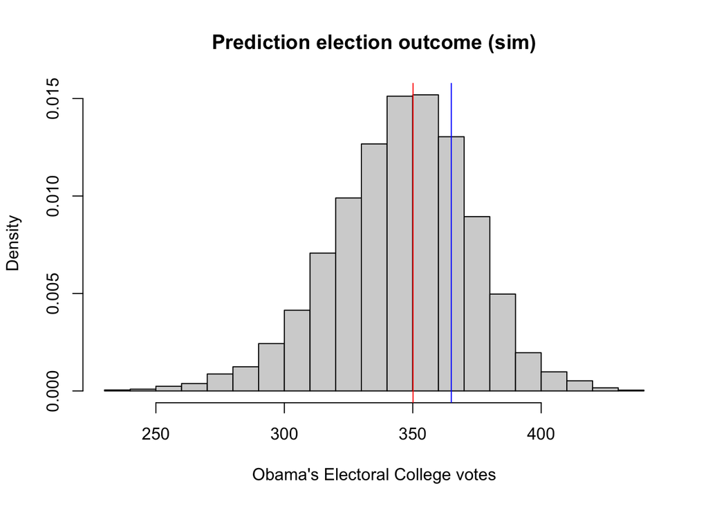

```r
set.seed(123)
sims <- 10000
n.states <- nrow(pred08.rel)
predobama.ev <- rep(NA, sims) #empty vector
for (i in 1:sims) {
  b.trial <- rbinom(n.states, size = 1, prob = pred08.rel$ppd) #setting up a bernoulli trial for a WIN/ NO WIN situation
  predobama.ev[i] <- sum(pred08.rel$EV[b.trial == 1]) #calculating the expected number of seats
}

hist(predobama.ev, freq = FALSE, #creating a histogram as described above
     main="Prediction election outcome (sim)",
     xlab= "Obama's Electoral College votes")
abline(v=365, col = "blue") #obama's actual votes are in blue
abline(v = mean(predobama.ev)+ 4, col = "red") #the predicvted number of votes is in red
```

###### Question 3

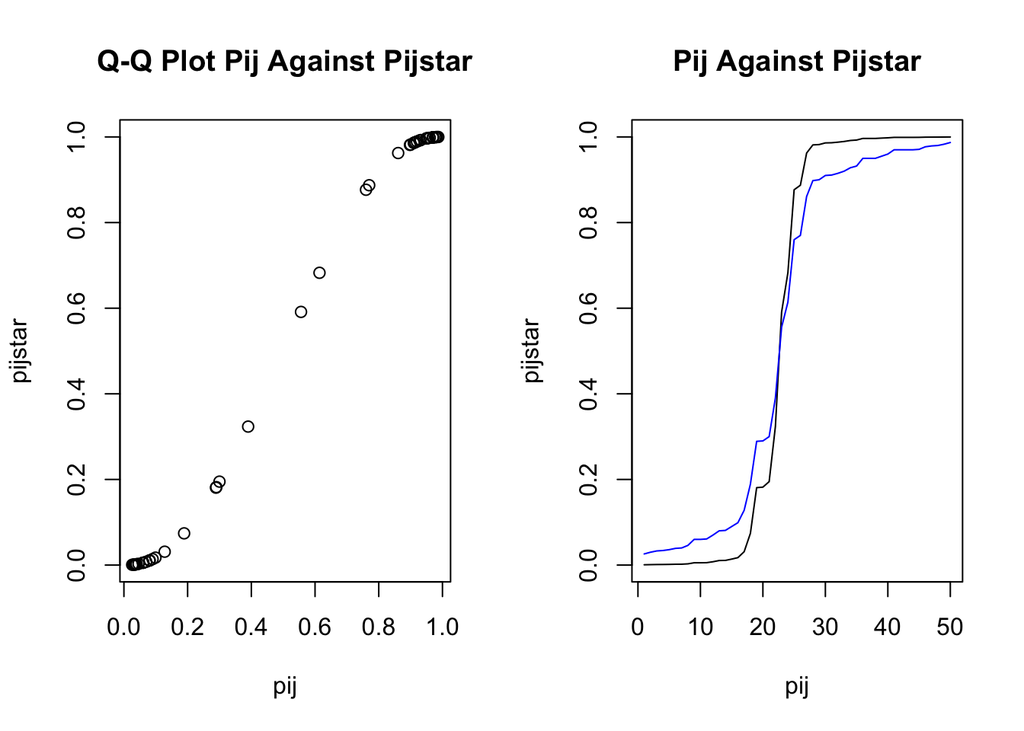

```r
pijstar <- pnorm(1.64*qnorm(pij)) #applying the equation provided by the mystical researcher in the sky

par(mfrow = c(1, 2)) #placing two charts next to each other
qqplot(pij,pijstar, main = "Q-Q Plot Pij Against Pijstar") #plotting the old and new probabilities against each other in qqplot
plot(sort(pijstar), type = "l", main = "Pij Against Pijstar", ylab = "pijstar", xlab = "pij") #plotting the old and new probabilities against each other as lines
lines(sort(pij), col = "blue")
```

Pij star shifts mean up and the standard deviation down of the cumulative distribution of pij, thus concentrating the probabilities and creating a steeper slope. This in effect increases the higher probabilities and decreases the lower ones.

###### Question 4

```r
pred08.rel$predwinstar <- ifelse(pijstar > 0.5, 1, 0)
predEV2 <- sum(pred08.rel$EV[pred08.rel$predwinstar == 1]) + 3 + 1
predEV2
```

```
## [1] 365
```

With the ifelse method the answer remains the same.

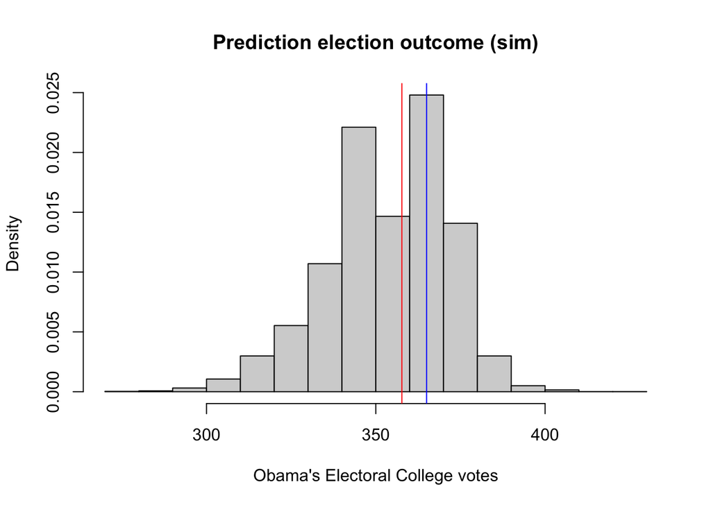

```r
set.seed(123)
predobama.ev.star <- rep(NA, sims)
for (i in 1:sims) {
  b.trial <- rbinom(n.states, size = 1, prob = pijstar)
  predobama.ev.star[i] <- sum(pred08.rel$EV[b.trial == 1])
}

hist(predobama.ev.star, freq = FALSE,
     main="Prediction election outcome (sim)",
     xlab= "Obama's Electoral College votes")
abline(v=365, col = "blue")
abline(v = mean(predobama.ev.star)+ 4, col = "red")
```

```r
mean(predobama.ev)
```

```
## [1] 346.1174
```

```r
mean(predobama.ev.star)
```

```
## [1] 353.6927
```

###### Question 5

```r
intrade$state.name <- intrade$statename #prepping and merging the data as I did in the first question
inpres <- merge(intrade, pres, by = "state.name")
inpres$pij2 = inpres$PriceD/ 100#creating the OG pij
inpres$pijstar2 <- pnorm(1.64*qnorm(inpres$pij2)) #creating the pijstar distribution

inpres.rel <- inpres %>%
  select(day, state.name, pijstar2, EV)

#filter for 120 days before November 4th
inpres.rel.120 <- inpres.rel  %>%
  filter(day >= as.Date("2008-07-07") & day < as.Date("2008-11-04"))
#inpres.rel.120$predwin2 <- ifelse(pijstar2 > 0.5, 1, 0) #if the probability is above 0.5 then predwin 2 gets a 1 and if not it gets a 0.



#aggregating the time series data by day (thanks to Laura for that)
#timeseries <- aggregate(inpres.rel.120$EV[inpres.rel.120$predwin2 == 1], list(category=inpres.rel.120$day[inpres.rel.120$predwin2 == 1]), sum)


#plot(timeseries, main = "Predicted EVs for Obama by data")


#commented out because it was an error
```

I got a plot but Rmd wouldn’t knit it. It’s OK cause it was wrong. My interpretation is thus that the plot is wrong but points for trying?

###### Question 6

```r
set.seed(123)
predobama.ev.star2 <- rep(NA, sims)
for (i in 1:sims) {
  b.trial3 <- rbinom(n.states, size = 1, prob = inpres.rel.120$pijstar2)
  predobama.ev.star2[i] <- sum(inpres.rel.120$EV[b.trial3 == 1])
}
```

Truly lost but I imagine I could somehow plot the mean(predobama.ev.star)+ 4 by day somehow? Not enough time to figure it out.

##### Section 2

```r
fate <- read_csv("linkfate.csv") #loading in and summarizing data
summary(fate)
```

```
##        X1              Male           Bachelor         relfreq
##  Min.   :   1.0   Min.   :0.0000   Min.   :0.0000   Min.   : 1.00
##  1st Qu.: 527.8   1st Qu.:0.0000   1st Qu.:0.0000   1st Qu.: 2.00
##  Median :1033.5   Median :0.0000   Median :0.0000   Median : 3.00
##  Mean   :1032.5   Mean   :0.4023   Mean   :0.2921   Mean   :37.21
##  3rd Qu.:1542.2   3rd Qu.:1.0000   3rd Qu.:1.0000   3rd Qu.:99.00
##  Max.   :2055.0   Max.   :1.0000   Max.   :1.0000   Max.   :99.00
##   religionlink   regionlink        moreno        province
##  Min.   :1.0   Min.   :1.000   Min.   :1.000   Length:1924
##  1st Qu.:2.0   1st Qu.:2.000   1st Qu.:2.000   Class :character
##  Median :2.0   Median :3.000   Median :3.000   Mode  :character
##  Mean   :2.4   Mean   :2.917   Mean   :2.653
##  3rd Qu.:3.0   3rd Qu.:4.000   3rd Qu.:3.000
##  Max.   :4.0   Max.   :4.000   Max.   :5.000
##    ownchtrust      religion
##  Min.   : 0.00   Length:1924
##  1st Qu.: 8.00   Class :character
##  Median :99.00   Mode  :character
##  Mean   :70.25
##  3rd Qu.:99.00
##  Max.   :99.00
```

###### Question 1

```r
prop.table(table(male = fate$Male, bach = fate$Bachelor)) #prop[ table calculating the proportion of people by gender and education
```

```
##     bach
## male         0         1
##    0 0.4251559 0.1725572
##    1 0.2827443 0.1195426
```

```r
mean(fate$relfreq[fate$relfreq != 99]) #mean without 99s
```

```
## [1] 2.105134
```

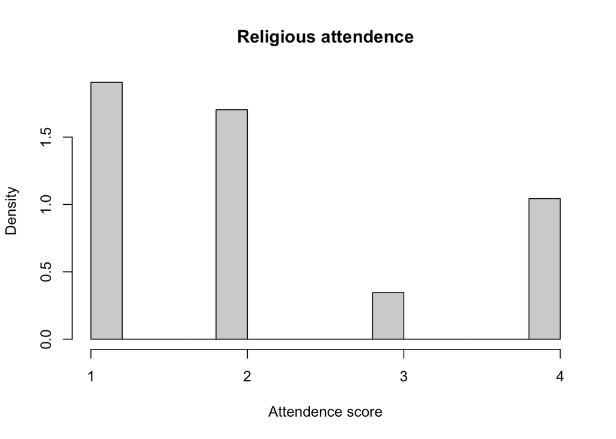

```r
hist(fate$relfreq[fate$relfreq != 99], freq = F, main = "Religious attendence", xlab = "Attendence score", xaxt ="n")
axis(side = 1, at= c(1, 2, 3, 4)) #labelling the values properly]
```

###### Question 2

```r
chtrust <- table(fate$ownchtrust[fate$ownchtrust != 99]) #creating a table without the 99s
chtrust2 <- prop.table(table(fate$ownchtrust)) # turning this into proportions justin case
chtrust #printing table to see the values
```

```
##
##   0   1   2   3   4   5   6   7   8   9  10
##  23   9  24  33  45  94  87 101  93  41  45
```

```r
mean(chtrust)
```

```
## [1] 54.09091
```

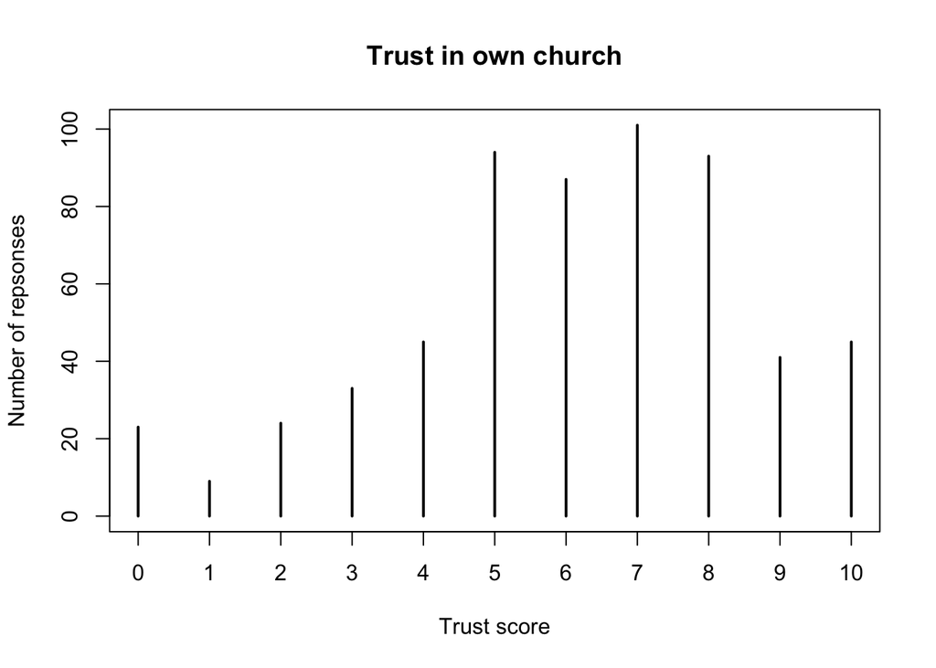

```r
plot(chtrust, main = "Trust in own church", xlab = "Trust score", ylab = "Number of repsonses")
```

The trust in church responses do not look perfectly normally distributed as there is a higher concentration of responses above 5 meaning that the distribution in non-symmetrical.

###### Question 3

```r
set.seed(123) #setting seed
sims2 <- 10000 #specifying sims
x <- seq(0, 10, 1) #creating a vector called x for the 0-10 scale
t <- seq(0, 8.0, 1) #creating a vector called t for the 0-8 scale
lt <- seq(-2, 2.5, 0.5) #specifying the sequence for the latent variable in a vector called lt
y <- rnorm(sims2, mean(x)) #y is a simulated normal distribution of x
ystar <- rnorm(sims2, mean(t)) #ystar is a simiulated normal distribution of t
ltdist <- rnorm(sims2, mean(lt)) #ltdist is a plot of the latent variable
```

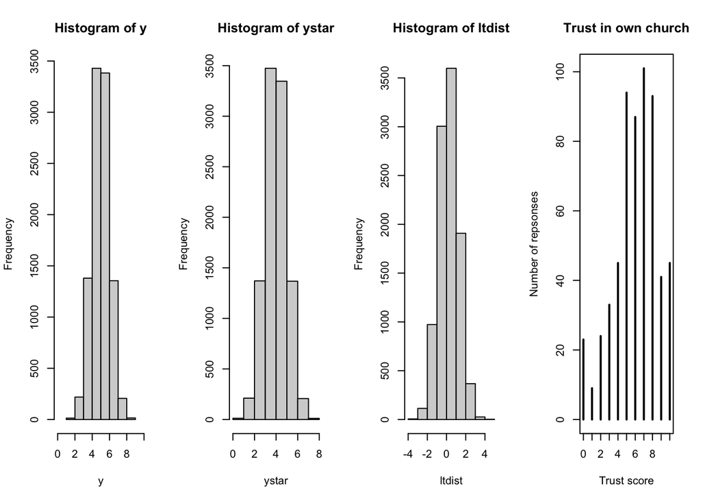

```r
par(mfrow= c(1,4)) # 3 barplots next to each other
hist(y, xlim = c(0,10), breaks = 10) #histograms for each distribution
hist(ystar, breaks = 7)
hist(ltdist, breaks = 7)
plot(chtrust, main = "Trust in own church", xlab = "Trust score", ylab = "Number of repsonses")
```

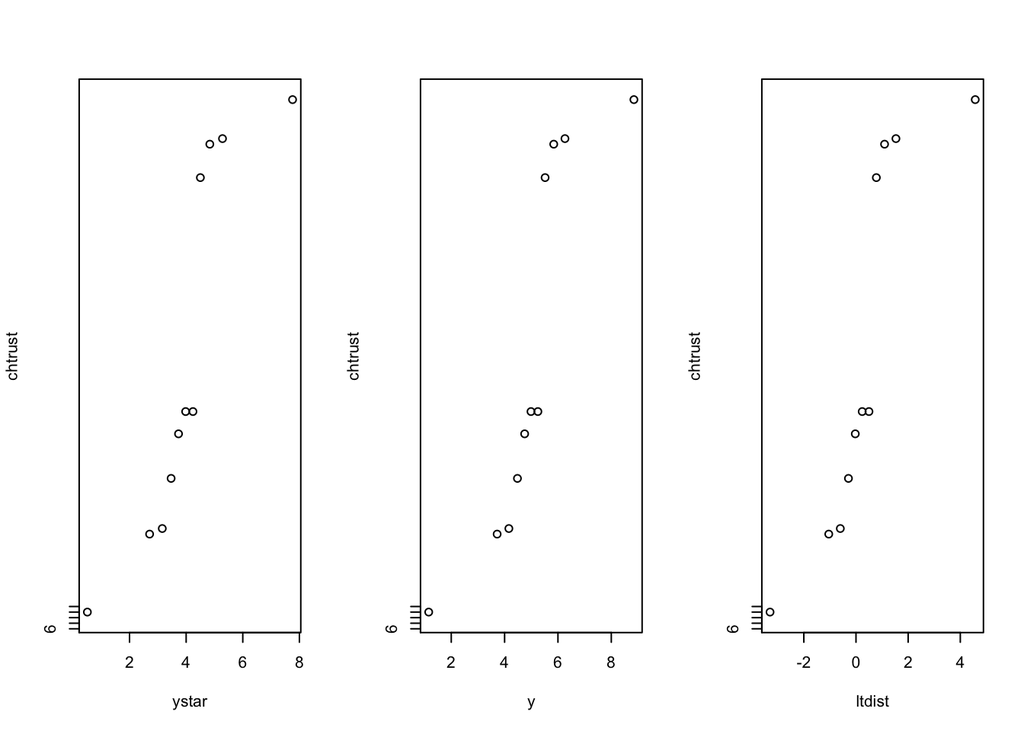

```r
par(mfrow = c(1,3)) #plotting all the qq plots againt chtrust
qqplot(ystar, chtrust)
qqplot(y, chtrust)
qqplot(ltdist, chtrust)
```

The QQ plots don’t line up very evenly. I couldn’t for the life of me figure out how to fix the y axis.

###### Question 4

```r
sort(tapply(fate$moreno, fate$province, mean), decreasing = T) #calculating and sorting the average moreno score by province
```

```
##                     Yukon Newfoundland and Labrador     Northwest Territories
##                  4.000000                  3.521739                  3.000000
##               Nova Scotia                   Alberta      Prince Edward Island
##                  2.862595                  2.788856                  2.727273
##              Saskatchewan                    Quebec          British Columbia
##                  2.724138                  2.715517                  2.664303
##             New Brunswick                  Manitoba                   Ontario
##                  2.617284                  2.557823                  2.384466
```

```r
sort(table(fate$province), decreasing = T) #lloking at the number of row entries by province
```

```
##
##                   Ontario          British Columbia                   Alberta
##                       515                       423                       341
##                  Manitoba               Nova Scotia                    Quebec
##                       147                       131                       116
##              Saskatchewan             New Brunswick Newfoundland and Labrador
##                        87                        81                        69
##      Prince Edward Island                     Yukon     Northwest Territories
##                        11                         2                         1
```

The Yukon has the highest average regional identity score. This is not a relibale indicator because only two responses came for the Yukon.

###### Question 5

```r
fate$region <- fate$province #creating a region variable

##subsetting inefficiently because it was more efficient than trying to figure out how to do it efficiently. I acknowledge this is short term thinking.
fate$region[fate$region == "Alberta" | fate$region == "Saskatchewan" | fate$region == "Manitoba"] <- "Prairies"
fate$region[fate$region == "Nova Scotia" | fate$region == "Newfoundland and Labrador" | fate$region == "Prince Edward Island" | fate$region == "New Brunswick"] <- "Maritimes"
fate$region[fate$region == "Northwest Territories" | fate$region == "Yukon"] <- NA
```

```r
regmean <- sort(tapply(fate$regionlink, fate$region, mean), decreasing = T) #the mean region link by region
regsd <- sort(tapply(fate$regionlink, fate$region, sd), decreasing = T) #the standard deviation by region
regmean #printing the regional link means
```

```
##         Prairies British Columbia        Maritimes          Ontario
##         3.015652         2.900709         2.883562         2.864078
##           Quebec
##         2.784483
```

The Prairies appear to have the highest average regional scorres with Quebec featuring the lowest

```r
sd(fate$regionlink)
```

```
## [1] 0.8516279
```

```r
sd(regmean)
```

```
## [1] 0.08329166
```

The average standard deviation across individual rows is much higher than the standard deviation of the regional means because the law of large numbers would dictate that as there are more respondents (like at the provincial level compared to individuals), then results will converge upon the mean thus lowering the standard deviation.

###### Question 6

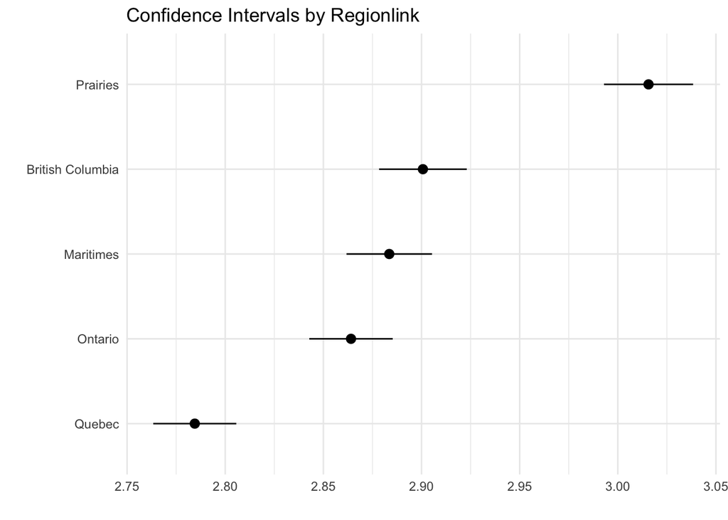

```r
se <- regsd/ sqrt(sims2)
ci <- data.frame(regmean - qnorm(0.995) * se, regmean + qnorm(0.995) * se)
ci$regmean <- regmean


colnames(ci)[1]<- "bottom"
colnames(ci)[2]<- "top"
ci <- rownames_to_column(ci, "region")

ggplot(ci, aes(x = regmean, xmin = bottom, xmax= top, y= reorder(region, regmean))) +
  geom_pointrange() +
  theme_minimal() +
  labs (x = "",
        y = "",
        title = "Confidence Intervals by Regionlink")
```

This chart plots the confidence intervals for each region by region link scores. The black dot is the regional mean with the lin spanning the bottom to the top of the confidence interval.